# Analysis of A673 EWS-FLI1 RNAseq Timecourse

## Setting up the environment

These are packages you will need for this notebook. For exact versions used, please refer to the session info at the bottom of this notebook.

```r
##########################################################################################
library('tidyverse')
library('RColorBrewer')
library('ggplot2')
library('tximport')
library('GenomicFeatures')
library('DESeq2')
library('org.Hs.eg.db')
library('ggrepel')
```

I want to set a base directory that we can use as a link to the directory where we will do most of the work. I use two directories here because the Workspace is what is pushed to GitHub and contains scripts and plot files, but the Repository is where more of the big data is stored that does not get pushed.

```r
##########################################################################################
generalDatasets = 'C:/Users/chughes/Documents/bccrc/projectsRepository/generalDatasets'
baseWorkspace = 'C:/Users/chughes/Documents/bccrc/projectsWorkspace/sorensenLab/relatedToDlg2'
baseRepository = 'C:/Users/chughes/Documents/bccrc/projectsRepository/sorensenLab/relatedToDlg2'
#generalDatasets = 'C:/Users/chris/OneDrive/Documents/bccrc/projectsRepository/generalDatasets'
#baseWorkspace = 'C:/Users/chris/OneDrive/Documents/bccrc/projectsWorkspace/sorensenLab/relatedToYbx1'
#baseRepository = 'C:/Users/chris/OneDrive/Documents/bccrc/projectsRepository/sorensenLab/relatedToYbx1'
```

## Data processing

Read in the sample annotation details and make the txdb that we can use later on for annotation gene identifiers.

```r
##########################################################################################
samples = read_tsv(paste(baseRepository, '/sequencing20210421_a673TimecourseRnaSeqOutput/sampleInfo.txt', sep = ''))
##
files = file.path(baseRepository, 'sequencing20210421_a673TimecourseRnaSeqOutput', paste(samples$barcode, '_', samples$batch, '_quant', sep = ''), 'quant.sf')
all(file.exists(files))
```

```
[1] TRUE
```

```r
##
myTxdb = makeTxDbFromGFF('C:/Users/chughes/Documents/bccrc/databases/hg38/gencode_gtf/2230c535660fb4774114bfa966a62f823fdb6d21acf138d4.gtf.gz')
```

```
Import genomic features from the file as a GRanges object ... OK
Prepare the 'metadata' data frame ... OK
Make the TxDb object ... Warning in .get_cds_IDX(mcols0$type, mcols0$phase) :
  The "phase" metadata column contains non-NA values for features of type stop_codon. This information was ignored.
OK
```

```r
k = keys(myTxdb, keytype = 'TXNAME')
tx2gene = AnnotationDbi::select(myTxdb, k, 'GENEID', 'TXNAME')
```

Now import the Salmon data.

```r
##########################################################################################
txi = tximport(files,
               type = 'salmon',
               tx2gene = tx2gene)
```

```
reading in files with read_tsv
1 2 3 4 5 6 7 8 9 10 11 12 13 14 15 16 17 18 19 20 21 22 23 24
transcripts missing from tx2gene: 21785
summarizing abundance
summarizing counts
summarizing length
```

```r
names(txi)
```

```
[1] "abundance"           "counts"              "length"              "countsFromAbundance"
```

```r
head(txi$counts)
```

```
                       [,1]     [,2]     [,3]     [,4]     [,5]     [,6]     [,7]     [,8]     [,9]    [,10]    [,11]    [,12]    [,13]    [,14]    [,15]    [,16]
ENSG00000000003.14 2653.725 2120.175 2333.001 3143.085 2874.720 3254.199 2431.001 2822.401 2779.069 1665.000 1838.807 2087.000 2828.000 2616.000 2682.000 2661.079
ENSG00000000005.5     0.000    2.000    0.000    0.000    0.000    0.000    0.000    0.000    0.000    0.000    0.000    0.000    0.000    0.000    0.000    0.000
ENSG00000000419.12 2735.319 2162.000 2280.576 2099.851 1905.013 2175.190 1832.001 2084.999 1988.000 1445.792 1629.815 1651.001 2325.157 2120.000 2140.000 2545.823
ENSG00000000457.13  235.880  220.577  166.718  378.421  362.107  425.254  282.649  308.828  243.109  190.033  211.892  231.683  346.133  284.387  257.644  275.893
ENSG00000000460.16 1389.770 1184.436 1090.879  661.202  649.217  709.030  388.570  416.841  412.784  575.728  663.027  641.836  641.027  606.083  669.095 1268.893
ENSG00000000938.12    2.000    3.000    0.000    0.000    2.000    1.000    3.000    4.000    1.000    1.000    1.000    0.000    1.000    2.000    1.000    2.000
                      [,17]    [,18]    [,19]    [,20]    [,21]    [,22]    [,23]    [,24]
ENSG00000000003.14 3228.373 2455.010 1529.570 1584.999 1483.000 2815.958 3624.450 2826.000
ENSG00000000005.5     0.000    0.000    0.000    0.000    0.000    0.000    0.000    1.000
ENSG00000000419.12 3105.334 2333.262 3173.936 3021.000 2718.082 2271.529 3018.450 2363.664
ENSG00000000457.13  303.985  267.521  478.975  446.899  404.248  224.672  296.540  199.270
ENSG00000000460.16 1617.992 1151.126  686.830  760.717  728.545 1085.810 1471.395 1073.408
ENSG00000000938.12    1.000    0.000    4.000    1.000    2.000    1.000    0.000    1.000
```

```r
##
txiAbundance = as.data.frame(txi$abundance)
colnames(txiAbundance) = paste(samples$sampleName,'_',samples$batch, sep = '')
ens.str = substr(rownames(txiAbundance), 1, 15)
txiAbundance$symbol = mapIds(org.Hs.eg.db, keys = ens.str, column = 'SYMBOL', keytype = 'ENSEMBL', multiVals = 'first')
txiAbundanceAvg = as_tibble(txiAbundance) %>%
  dplyr::select(symbol, day0_setA:day22_setC) %>%
  pivot_longer(cols = day0_setA:day22_setC, names_to = 'sampleName', values_to = 'tpm') %>%
  dplyr::mutate(day = factor(sub('(.*)_set[ABC]$', '\\1', sampleName), levels = c('day0','day7','day9','day10','day11','day14','day17','day22'))) %>%
  dplyr::mutate(log2Tpm = log2(tpm + 1)) %>%
  dplyr::select(-sampleName) %>%
  group_by(symbol, day) %>%
  summarize(meanTpm = mean(log2Tpm, na.rm = TRUE)) %>%
  pivot_wider(id_cols = symbol, names_from = day, values_from = meanTpm)
saveRDS(txiAbundanceAvg, paste(baseRepository, '/sequencing20210421_a673TimecourseRnaSeqOutput/dataset_txiAllSamplesSummarizedMeans.rds', sep = ''))

##
tpmCalc = function(x){
  log2Tpm = log2(x + 1)
}
txiAbundanceNoAvg = as_tibble(txiAbundance) %>%
  dplyr::select(symbol, day0_setA:day22_setC)
  #dplyr::mutate(across(c(day0_setA:day22_setC), tpmCalc))
saveRDS(txiAbundanceNoAvg, paste(baseRepository, '/sequencing20210421_a673TimecourseRnaSeqOutput/dataset_txiAllSamples.rds', sep = ''))
```

Construct the DESeq2 dataset.

```r
##########################################################################################
ddsTxi = DESeqDataSetFromTximport(txi,
                                  colData = samples,
                                  design = ~ sampleName)
##
dds = DESeq(ddsTxi)
```

```
using 'avgTxLength' from assays(dds), correcting for library size
```

```r
keep = rowSums(counts(dds)) >= 10
dds = dds[keep,]
```

Perform comparisons between samples.

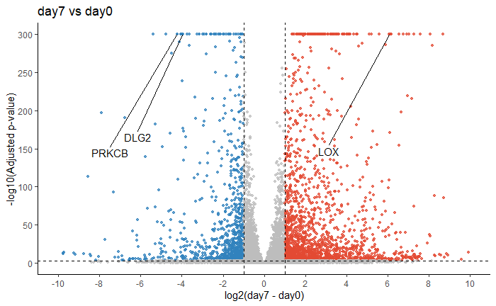

```r
##########################################################################################
datasetFirst = 'day7'
datasetSecond = 'day0'
res = results(dds, contrast = c('sampleName', datasetFirst, datasetSecond))
ens.str = substr(rownames(res), 1, 15)
res$symbol = mapIds(org.Hs.eg.db,
                     keys=ens.str,
                     column="SYMBOL",
                     keytype="ENSEMBL",
                     multiVals="first")
resOrdered = res[order(res$pvalue),]

##
saveRDS(as.data.frame(resOrdered),
        paste(baseRepository, '/sequencing20210421_a673TimecourseRnaSeqOutput/dataset_deseq2_', datasetFirst, '-', datasetSecond, '.rds', sep = ''))
write.csv(as.data.frame(resOrdered),
          file = paste(baseRepository, '/sequencing20210421_a673TimecourseRnaSeqOutput/dataset_deseq2_', datasetFirst, '-', datasetSecond, '.csv', sep = ''))

##
#resLFC = lfcShrink(dds, coef = paste('treatment_',datasetFirst,'_vs_',datasetSecond, sep = ''), type = "apeglm")
#resLFC
#plotMA(resLFC, ylim = c(-2,2))
rnaExp = as.data.frame(resOrdered)
rnaExp$logPValue = -log10(rnaExp$padj)
rnaExp$logPValueScaled = ifelse(rnaExp$logPValue > 300, 300, rnaExp$logPValue)
rnaExp$pColors = ifelse(rnaExp$padj <= 0.001 & rnaExp$log2FoldChange >= 1, brewer.pal(3,'OrRd')[3],
                        ifelse(rnaExp$padj <= 0.001 & rnaExp$log2FoldChange <= -1, brewer.pal(3,'Blues')[3], brewer.pal(3,'Greys')[2]))
goi = c('DLG2','LOX','PRKCB')
rnaExp$pText = ifelse(rnaExp$symbol %in% goi, rnaExp$symbol, '')
##
ggplot(rnaExp, aes(log2FoldChange, logPValueScaled)) +
  geom_point(size = 1, color = rnaExp$pColors, alpha = 0.75) +
  labs(x = paste('log2(',datasetFirst,' - ',datasetSecond,')', sep = ''), y = '-log10(Adjusted p-value)', title = paste(datasetFirst,' vs ',datasetSecond, sep='')) +
  geom_text_repel(label = rnaExp$pText, nudge_x = -3, nudge_y = -150, max.overlaps = 15000) +
  scale_x_continuous(limits = c(-10,10), breaks = seq(-10,10,2)) +
  scale_y_continuous(limits = c(0,300), breaks = seq(0,500,50)) +
  geom_vline(xintercept = c(-1,1), linetype = 'dashed') +
  geom_hline(yintercept = -log10(0.001), linetype = 'dashed') +
  theme_classic()
##
ggsave(paste(baseRepository, '/sequencing20210421_a673TimecourseRnaSeqOutput/scatter_deseq2_', datasetFirst, '-', datasetSecond, '.pdf', sep = ''),
       height = 2, width = 2, useDingbats = FALSE)
```

Compare the different samples using a PCA.

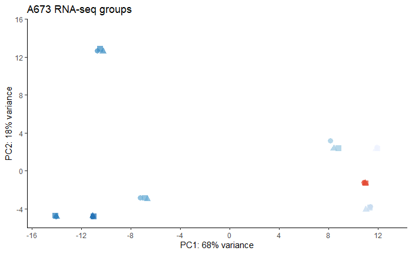

```r
##########################################################################################
vsd = vst(dds, blind = FALSE) #variance stabilizing normalization of the data
#extract the data for the MDS analysis itself
mdsPlot = plotPCA(vsd, intgroup=c('sampleName','batch'), returnData = TRUE)
mdsPlot$sampleName = factor(mdsPlot$sampleName, levels = c('day0','day7','day9','day10','day11','day14','day17','day22'))
percentVar = round(100 * attr(mdsPlot, 'percentVar'))
#make the ggplot
ggplot(mdsPlot, aes(PC1, PC2, color = sampleName, shape = batch)) +
  geom_point(size = 3, alpha = 0.75) +
  scale_color_manual(values = rep(c(brewer.pal(3,'Blues')[3], brewer.pal(3,'OrRd')[3], brewer.pal(7,'Blues')[1:6]),3)) +
  scale_x_continuous(limits = c(-15,13), breaks = seq(-20,20,4)) +
  scale_y_continuous(limits = c(-5,15), breaks = seq(-20,20,4)) +
  labs(x = paste0('PC1: ', percentVar[1], '% variance'),
       y = paste0('PC2: ', percentVar[2], '% variance'),
       title = 'A673 RNA-seq groups') +
  theme_classic() +
  theme(legend.position = 'none')
#save the plot
ggsave(paste(baseRepository, '/sequencing20210421_a673TimecourseRnaSeqOutput/pcaplot_a673ShEwsFli1AbundanceVsn.pdf', sep = ''),
       height = 2, width = 2, useDingbats = FALSE)
```